# Coursera Practical Machine Learning - Prediction Assignment Writeup

Ricardo Aguiar

2 de outubro de 2016

# Instructions

Using devices such as Jawbone Up, Nike FuelBand, and Fitbit it is now possible to collect a large amount of data about personal activity relatively inexpensively. These type of devices are part of the quantified self movement – a group of enthusiasts who take measurements about themselves regularly to improve their health, to find patterns in their behavior, or because they are tech geeks. One thing that people regularly do is quantify how much of a particular activity they do, but they rarely quantify how well they do it. In this project, your goal will be to use data from accelerometers on the belt, forearm, arm, and dumbell of 6 participants. They were asked to perform barbell lifts correctly and incorrectly in 5 different ways. More information is available from the website here: http://groupware.les.inf.puc-rio.br/har (see the section on the Weight Lifting Exercise Dataset).

## Summary

In this project we will build some predictions about the ways in which participants experiment did the exercise in order to identify the classification (correctly and incorrectly in 5 different ways).

## Global options

Open libraries.

```r
library(caret)
library(rattle)
```

Setting the working directory and download data.

```r
if(!file.exists("~/projetos/projetos_R/prediction_assignment_writeup/")){
  dir.create("~/projetos/projetos_R/prediction_assignment_writeup/")
}
setwd("~/projetos/projetos_R/prediction_assignment_writeup/")

fileName <- "pml-training.csv"
if (!file.exists(fileName)){
  fileURL <- "https://d396qusza40orc.cloudfront.net/predmachlearn/pml-training.csv"
  download.file(fileURL, fileName, method="curl")
}

fileName <- "pml-testing.csv"
if (!file.exists(fileName)){
  fileURL <- "https://d396qusza40orc.cloudfront.net/predmachlearn/pml-testing.csv"
  download.file(fileURL, fileName, method="curl")
}

set.seed(32343)
```

## Openning and cleaning the data

```r
pml_training <- read.csv("pml-training.csv", header=T, na.strings=c("NA", "#DIV/0!"))
pml_testing <- read.csv("pml-testing.csv", header=T, na.string=c("NA", "#DIV/0!"))

pml_training_set <- pml_training[, apply(pml_training, 2, function(x) !any(is.na(x)))]
pml_testing_set <- pml_testing[, apply(pml_testing, 2, function(x) !any(is.na(x)))]

pml_training_set <- pml_training_set[,-c(1:7)]
pml_testing_set <- pml_testing_set[,-c(1:7)]

dim(pml_training_set)
```

```
## [1] 19622    53
```

```r
dim(pml_testing_set)
```

```
## [1] 20 53
```

## Create partitions

We create the partitions (training and testing) with the pml_training_set data.

```r
inTrain <- createDataPartition(y=pml_training_set$classe, p=0.75, list=FALSE)
training <- pml_training_set[inTrain,]
testing <- pml_training_set[-inTrain,]
```

## Testing models

We define model_fit1 using the method “rpart” (Recursive Partitioning and Regression Trees). The accuracy is around .50.

```r
model_fit1 <- train(classe ~ .,method="rpart",data=training)
```

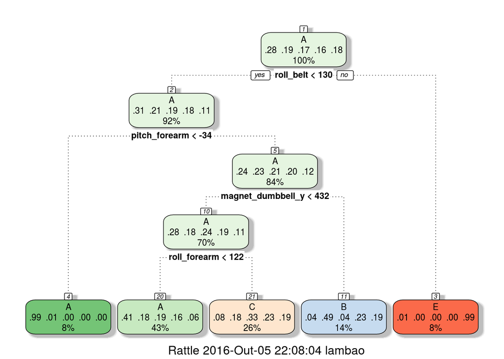

```r
fancyRpartPlot(model_fit1$finalModel)
```

```r
pred1 <- predict(model_fit1,newdata=testing)
cMatrix1 <- confusionMatrix(pred1,testing$classe)
cMatrix1$table
```

```
##           Reference
## Prediction    A    B    C    D    E
##          A 1255  383  382  362  130
##          B   25  327   31  134  114
##          C  112  239  442  308  236
##          D    0    0    0    0    0
##          E    3    0    0    0  421
```

```r
cMatrix1$overall[1]
```

```
##  Accuracy
## 0.4985726
```

The model_fit2 is defined by the method “rf” (random forest) and that has a better accuracy than the method “rpart”. The accuracy is around .99.

```r
model_fit2 <- train(classe ~ .,method="rf",data=training, trControl =trainControl(method = "cv", number=10, allowParallel=TRUE), verbose=FALSE)
pred2 <- predict(model_fit2,newdata=testing)
cMatrix2 <- confusionMatrix(pred2,testing$classe)
cMatrix2$table
```

```
##           Reference
## Prediction    A    B    C    D    E
##          A 1393    9    0    0    0
##          B    1  936    7    0    0
##          C    0    4  845    8    3
##          D    0    0    3  796    1
##          E    1    0    0    0  897
```

```r
cMatrix2$overall[1]
```

```
##  Accuracy
## 0.9924551
```

```r
model_fit3 <- train(classe ~ .,method="gbm",data=training, trControl =trainControl(method = "cv", number=10, allowParallel=TRUE), verbose=FALSE)
pred3 <- predict(model_fit3,newdata=testing)
cMatrix3 <- confusionMatrix(pred2,testing$classe)
cMatrix3$table
```

```
##           Reference
## Prediction    A    B    C    D    E
##          A 1393    9    0    0    0
##          B    1  936    7    0    0
##          C    0    4  845    8    3
##          D    0    0    3  796    1
##          E    1    0    0    0  897
```

```r
cMatrix3$overall[1]
```

```
##  Accuracy
## 0.9924551
```

## Conclusion

```r
predictFinal <- predict(model_fit2, newdata=pml_testing_set)

predictFinal
```

```
##  [1] B A B A A E D B A A B C B A E E A B B B
## Levels: A B C D E
```